# DESN2003: Research for Innovation

Week 2: Research Frameworks (From Instinct to Method)

Dr. Hongshan Guo

# Picking Up Where We Left Off

## Last Week: Your Instagram Feature Ideas

Remember the persona exercise?

- You picked someone you know
- Identified what they **love** and **hate** about Instagram
- Proposed a **new feature** Instagram is “dying for”

**Today’s Big Question**

How do you know your feature idea is **actually needed**—and not just a clever assumption?

## Quick Pulse Check

**Turn to a neighbor (2 minutes):**

1. What feature did you propose last week?
2. What made you think Instagram *needs* this?

We’ll come back to these ideas throughout today’s session.

# Case Study: Validating Your Feature

## The Challenge

You’ve identified a gap. Now let’s stress-test it.

**Your Task (15 minutes, in pairs)**

Pick ONE of your feature ideas and work through these questions:

1. **The Gap:** What specific user problem or frustration does this feature solve?
2. **The Evidence:** What makes you believe this gap exists? (Personal experience? Observations? Something you read?)
3. **The Assumption Check:** Could this just be *your* preference, or is it widespread?
4. **The Landscape:** Does this feature exist in a competitor app (TikTok, BeReal, Snapchat)? If yes, why might Instagram not have it? If no, why might that be?
5. **The Validation:** If you had to prove this gap is real, what would you do?

## Debrief: What Did You Discover?

**Let’s hear from a few groups:**

- What gap did you identify?
- How confident are you that it’s real?
- What would you need to validate it?

**Notice Something?**

You just did **research thinking**—without formal methods. Now let’s name what you were doing.

# The Research You Already Did

## Planting Seeds: Methods You Used Without Knowing

When you worked through that case study, you were already doing research:

**What You Did:**

- Recalled how someone uses Instagram
- Noticed their frustrations
- Compared to your own experience
- Thought about “would others feel this way?”
- Imagined how to test your idea

**The Formal Name:**

- **Ethnographic observation** (watching behavior)
- **Pain point analysis** (identifying friction)
- **Comparative analysis** (self vs. others)
- **Generalizability question** (sample → population)
- **Research design thinking** (validation strategy)

**The Point**

Research isn’t something foreign—it’s **systematic thinking** you already do naturally. Today we formalize it.

## The Validation Methods You Proposed

When asked “how would you prove this gap is real?”, you likely suggested:

- **“Ask more people”** → That’s a **survey** or **interview**
- **“Watch how people actually use it”** → That’s **observational research** or **usability testing**
- **“Look at app reviews/complaints”** → That’s **secondary research** / **content analysis**
- **“Check if competitors have this feature”** → That’s **competitive analysis**
- **“Test it with a small group”** → That’s **prototype testing** or **A/B testing**

These are all legitimate research methodologies. The question is: **which one fits your question?**

# Why Research Frameworks Matter

## From Gut Feeling to Systematic Inquiry

### Without Frameworks

- “I think users want this”
- “My friend complained about it”
- “It makes sense to me”
- “I’ve seen people struggle”

**Problem:** Confirmation bias, small samples, untested assumptions

### With Frameworks

- “User interviews revealed a pattern”
- “Survey data shows 67% experience this”
- “Competitive analysis found a gap”
- “A/B test showed 40% improvement”

**Strength:** Systematic, defensible, scalable

**The Shift**

Research frameworks don’t replace intuition—they **validate and strengthen** it.

# Classification of Research

## The Big Picture: Types of Research

**Applied vs. Fundamental**

### Basic (Fundamental) Research

- Expanding knowledge without immediate practical application
- “How do humans process visual information?”
- Builds theory and understanding

*Your Instagram work:* Not this (you have a practical goal)

### Applied Research

- Solving specific, real-world problems
- “How can we reduce checkout abandonment?”
- Directly informs design decisions

*Your Instagram work:* **This one!** You’re solving a real user problem.

## Quantitative vs. Qualitative

### Quantitative Research

- Numbers and statistics
- “How many users experience this?”
- “What’s the conversion rate?”
- Measures **magnitude** and **frequency**

**Your case study:** “Would others feel this way?” → needs quantitative validation

### Qualitative Research

- Non-numerical data (text, interviews, observations)
- “Why do users feel frustrated?”
- “How do they describe the problem?”
- Explores **depth** and **meaning**

**Your case study:** Understanding the persona’s frustrations → qualitative insight

**Mixed Methods**

Often the most powerful approach: **Qualitative** to understand the “why” → **Quantitative** to measure the “how many”

## Why Classification Matters

- **Choosing the right method** for your research question
- **Common language** to discuss and compare approaches
- **Distinguish fads from real trends** (is this a genuine gap or a passing complaint?)

**Back to Your Feature Idea**

If you want to validate your Instagram feature:

- **Qualitative first:** Interview 5-10 users to understand the problem deeply
- **Quantitative second:** Survey 100+ users to see if the pattern holds broadly

# Research Gap: The Heart of Innovation

## Three Types of Research: A Preview

### Discovery Research

**“What’s the real problem?”**

- Before any solution exists
- Exploring unknown territory
- Output: Insights, opportunities

### Validation Research

**“Does this solution work?”**

- After prototyping
- Testing specific hypotheses
- Output: Go/no-go decisions

### Innovation Research

**“What doesn’t exist yet?”**

- Seeking 10x, not 10%
- Combining domains
- Output: New categories

**This Course’s Core Question**

Can you distinguish **incremental improvement** (better button color) from **genuine innovation** (new category of interaction)? Research methodology gives you that power.

## What Is a Research Gap?

A research gap is an area where **no or little information is available**

- It represents an opportunity for new research and discovery
- It’s where innovation lives

**Types of gaps:**

- A concept or idea that **hasn’t been studied at all**
- Existing research is **outdated** and needs updating
- A **specific population** hasn’t been well studied
- A **context** hasn’t been explored (e.g., Instagram for Gen Z creators vs. casual users)

## Your Instagram Feature = A Research Gap Hypothesis

**Think About It**

When you proposed your feature, you were essentially saying:

*“There’s a gap between what users need and what Instagram currently offers.”*

**But is it a real gap?**

- Maybe Instagram already tried it and it failed (you don’t know the history)
- Maybe only a small subset of users want it (your sample is biased)
- Maybe there’s a technical/business reason it doesn’t exist
- Maybe it exists and you just haven’t found it

**Research helps you answer:** Is this gap real, significant, and addressable?

## Gap Validation: A Concrete Example

### The Hypothesis

*“Instagram needs a ‘close friends only’ feed so users see less influencer content”*

**Sounds reasonable. But let’s validate:**

1. **Does it exist?** → Instagram has “Close Friends” for Stories (2018). Why not feed?
2. **Was it tried?** → Twitter had “Lists” for years. Low adoption.
3. **What do users say?** → Reddit: “I want chronological, not filtered”
4. **What does research say?** → Paradox of choice literature suggests more options ≠ more satisfaction

### The Verdict

**Gap refined:** Users want *control*, not necessarily *close friends*. The real gap might be: “Why doesn’t Instagram let me choose my algorithm?”

**This is what validation looks like:**

- Your original instinct: partially right
- Reality: more nuanced
- New direction: more innovative

**Time spent:** 30 minutes of searching **Value:** Didn’t waste a semester on wrong question

## Methods to Identify & Validate Research Gaps

**For Academic Research:**

- Systematic literature review
- “Suggestions for future research” sections
- Heavily-cited seminal works
- Databases: Web of Science, SAGE, Research Rabbit
- Consultation with experts

**For Product/Design Research:**

- User interviews & pain point analysis
- App store reviews & social media complaints
- Competitive analysis
- Usage analytics & drop-off data
- Customer support ticket patterns

**The Parallel**

Academic researchers read papers to find gaps. Product researchers talk to users and analyze data. **Same goal, different sources.**

# A Quick Side-Note: A/B Testing

## The Scientific Approach to Design Decisions

**A/B Testing:** A method to compare two versions of a variable to determine which performs better

- **Origin:** Derived from *Randomized Controlled Trials* (RCTs) in scientific research
- **Application:** Widely used in *product development*, *marketing*, and *user experience design*

**Connection to Your Case Study**

If your Instagram feature got built, A/B testing would be how they’d validate it actually works better than the current design.

## Key Concepts

1. **Control Group:** The existing version (A)
2. **Treatment Group:** The new version being tested (B)
3. **Randomization:** Users randomly assigned to A or B
4. **Metrics:** Predefined measures of success
5. **Statistical Significance:** Ensuring results aren’t due to chance

**Remember**

The only difference between A and B should be the element you’re testing!

## The A/B Testing Process

1. **Hypothesis**: Formulate a testable prediction
2. **Design**: Create version A and B
3. **Implement**: Set up the test environment
4. **Collect Data**: Run the test and gather results
5. **Analyze**: Determine statistical significance
6. **Conclude**: Make data-driven decisions

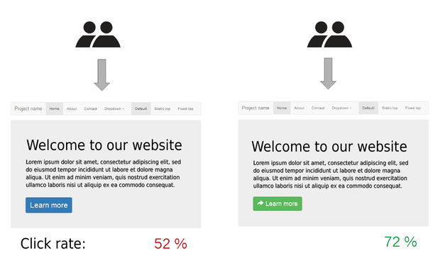

What do you know about click through rate?

## Case Study - Button Color Test

**Hypothesis**: *A green “Learn More” button will increase conversions compared to the current blue button.*

**Results**:

- Version A (Blue): 100 sign-ups from 1000 views (10% conversion)
- Version B (Green): 150 sign-ups from 1000 views (15% conversion)
- *50% increase* in conversion rate, statistically significant (p < 0.05)

**Your Feature Idea**

How would you A/B test it? What would “success” look like in metrics?

## The Research That Shipped: Spotify Wrapped

**Reverse-engineering the methodology behind a viral feature:**

**What They Researched (Discovery):**

- User behavior analysis: People share personal data when it’s beautiful
- Social psychology literature: FOMO + identity expression = virality
- Competitive gap: No one else was doing year-end summaries

**Method used:** Behavioral analytics + psychology literature + A/B testing

**The Research Questions Behind It:**

1. “What data do users find personally meaningful?” (Discovery)
2. “What format maximizes sharing?” (Validation via A/B)
3. “What emotional triggers drive virality?” (Literature)

**Result:** 120M+ shares annually, cultural phenomenon

**The Pattern**

**Discover** (what do users value?) → **Validate** (which format works?) → **Innovate** (create a new category: year-end data stories)

# Research Methodologies: A Toolkit

## Quantitative Methods (The Numbers)

**Measuring & Comparing:**

- **Survey:** Collect data from many users
- **Experimental:** Test cause-and-effect
- **A/B Testing (RCTs):** Compare two versions
- **Correlation:** Find relationships between variables

**Analyzing Patterns:**

- **Data Mining & Analytics:** Discover patterns in large datasets
- **Longitudinal Analysis:** Track changes over time
- **Meta-Analysis:** Combine results from multiple studies

**For Your Instagram Feature**

Survey could validate how widespread the problem is. A/B testing could measure if your solution works.

## Qualitative Methods (The Why)

**Understanding People:**

- **Interviews:** Deep conversations with users
- **Ethnography:** Immerse in user’s environment
- **Case Study:** In-depth analysis of specific situation
- **Phenomenology:** Understand lived experiences

**Analyzing Content:**

- **Content Analysis:** Systematically analyze text/media
- **Grounded Theory:** Build theory from data
- **Narrative Analysis:** Explore personal stories

**For Your Instagram Feature**

Interviews would help you understand WHY users are frustrated. Ethnography could reveal how they actually use the app (vs. how they say they do).

## Mixed Methods: Best of Both Worlds

When you need both **depth** (qualitative) and **scale** (quantitative):

- **Sequential Explanatory:** Quantitative first, then qualitative to explain
- **Sequential Exploratory:** Qualitative first, then quantitative to validate
- **Concurrent Triangulation:** Both at once, compare results

**The Instagram Approach**

1. **Qualitative:** Interview 10 users about their frustrations (find patterns)
2. **Quantitative:** Survey 500 users to see if patterns hold (validate scale)
3. **Experimental:** A/B test the feature with a subset (measure impact)

# Applying the Frameworks

## Exercise: Classify Your Research Approach

**Return to your Instagram feature idea (5 minutes):**

1. Is validating your feature **applied** or **fundamental** research?
2. Would you start with **qualitative** or **quantitative** methods? Why?
3. What specific method would you use first?
4. How would you know if the gap is real vs. assumed?

**Share Out**

Be ready to explain your reasoning to the class.

## Scenarios: What Type of Research?

> What type of research is this and why?
1. A team conducts **eye-tracking studies** to understand how users interact with a new stories feature.
   - *Applied, Quantitative, Experimental/Observational*
2. A UX researcher analyzes the **evolution of navigation patterns** in mobile apps over the past decade.
   - *Applied, Mixed Methods, Longitudinal/Content Analysis*
3. A startup runs **A/B tests** on their e-commerce checkout process.
   - *Applied, Quantitative, Experimental (RCT)*

## Research Gap Practice: VUI Abstracts

*Find the research gap sentence, then identify the actual gap:*

> **Abstract 1:** “Voice User Interfaces (VUIs) are increasingly prevalent in smart home devices, yet **their accessibility for users with visual and motor impairments remains understudied**. We conducted a mixed-methods study…”

> **Abstract 2:** “Our findings indicate that while VUIs can enhance independence for older adults, **current designs often do not adequately address age-related changes** in cognition, hearing, and speech production…”

> **Abstract 3:** “However, **current VUI design frameworks do not adequately account for these cultural variations**, potentially leading to reduced usability…”

**Overarching gap:** VUI design lacks consideration for diverse user populations (accessibility, age, culture)

# Wrap-Up

## Today’s Key Takeaways

1. **Research thinking is natural**—you already do it. Frameworks make it systematic.
2. **Research gaps are opportunities**—your feature idea is a hypothesis about a gap.
3. **Applied vs. Fundamental** tells you the goal; **Quant vs. Qual** tells you the approach.
4. **Start qualitative** to understand the “why,” then go **quantitative** to measure the “how many.”
5. **Validation transforms assumptions into insights**—that’s the power of research.

## The Bridge: From Instinct to Evidence

**Week 1:** You had an instinct

- “Instagram needs this feature”
- Based on observing someone you know
- A hypothesis waiting to be tested

**Week 2:** You learned to validate it

- Is this a real research gap?
- What methods would test it?
- How do you move from assumption to evidence?

**Next Week:** We’ll dive into **Literature Review**—how to find what’s already known so you don’t reinvent the wheel.

## The Question We’re Leaving Open

**Think About This Before Next Week**

When you checked “does this exist in a competitor app?”—how thorough was that search?

- Did you check all competitors, or just the ones you know?
- Did you look at academic research on similar features?
- Did you find out if Instagram tried this before and it failed?
- Do you know what the *state of the art* is in this space?

**The uncomfortable truth:** Your “gap” might not be a gap at all—you just haven’t looked hard enough yet.

**Next week:** How to *systematically* map what’s already known—so your innovation is actually new.

# Doc 0: Your Extended Abstract

## Two Tracks: Choose Your Path

**Your Work Can Take Two Forms**

Throughout this course, you can frame your deliverables through **either lens**:

|  | **Frontier Research (Technologist)** | **Applied Research (Builder-Maker)** |
| --- | --- | --- |
| **Doc 0** | Extended Abstract | Product Research Brief |
| **Doc 0.1** | Literature Review | Landscape Intelligence Report |
| **Doc 0.2** | Methodology Section | Research Playbook |
| **Doc 1** | Research Paper | Design Case Study |

**Same rigor. Same skills. Different audience.**

Choose based on your interests: Are you drawn to being a **technologist/researcher** who shapes the field with new knowledge? Or a **product designer** who ships research-backed features? Both are valuable. Both use the same methodology.

## What Is an Extended Abstract?

An extended abstract is **not** a summary of a paper you haven’t written yet.

It’s a **pitch for your research**:

- What problem are you investigating?
- Why does it matter (to you, to the field, to the world)?
- What’s your angle or approach?
- What might you find or contribute?

**Think of It As…**

A movie trailer for your research. You’re convincing someone it’s worth watching—without spoiling the ending (because you don’t know it yet).

## Extended Abstract: The Structure

**≤500 words. Plain text. No citations needed.**

**What to include:**

1. **The Problem** (2-3 sentences)
   - What issue are you investigating?
2. **Why It Matters** (2-3 sentences)
   - Personal significance + broader relevance
3. **The Gap** (1-2 sentences)
   - What’s missing or understudied?
4. **Your Approach** (2-3 sentences)
   - How will you investigate this?
5. **Potential Contribution** (1-2 sentences)
   - What might we learn?
6. **Next Steps** (optional)
   - Bullet points on what you’ll do next

## What Makes a Strong Extended Abstract?

**Do this:**

- Be specific about the problem
- Show genuine curiosity
- Scope appropriately (not too broad, not too narrow)
- Connect personal interest to broader significance
- Be honest about what you don’t know yet

**Avoid this:**

- Vague topics (“I want to study sustainability”)
- Just describing *what* without *why*
- Overpromising results you can’t deliver
- Trying to sound “academic” at the expense of clarity
- Including citations (save those for Doc 0.1)

## Example: Good vs Bad Extended Abstract

### Bad Abstract

*“I want to study Instagram and mental health. Social media is bad for people. I will interview some users and see what they think. This is important because many people use Instagram.”*

**What’s wrong:**

- No specific research question
- “Social media is bad” — assumption, not finding
- “Interview some users” — no methodology thinking
- “Many people use Instagram” — so what?

### Good Abstract

**Credibility check:** Could a stranger understand exactly what you’re studying and why it matters? If not, revise.

## Your Task: Doc 0 Due Week 4

**For the next two weeks:**

1. Choose a topic you’re genuinely curious about
2. Draft your extended abstract (≤500 words)
3. Use the structure: Problem → Significance → Gap → Approach → Contribution
4. Submit by **Tuesday, Feb 10, 12:00 PM noon**

**Starting Point**

Your Instagram feature idea could be the seed—or pivot to something else entirely. What matters is that YOU find it interesting.

## Questions?

Let’s discuss!

**Office hours:** By appointment

**Next week:** Literature Review—finding what’s already known

DESN2003 Research for Innovation